# Projeto Finanças

Usaremos seguintes ações da bolsa :

- BRFS3: A BRF é uma empresa transnacional brasileira do ramo alimentício, fruto da fusão entre Sadia e Perdigão, duas das principais empresas de alimentos do Brasil.
- JBSS3: JBS é uma empresa brasileira do setor de alimentos fundada em 1953 em Goiás. A companhia opera no processamento de carnes bovina, suína, ovina, de frango, de peixe e plant-based, além de atuar no processamento de couros
- BEEF3: Minerva Foods é uma empresa brasileira de alimentos fundada em 1924 na cidade de Barretos. A companhia tem atuação na comercialização de carne in natura, couros, derivados, e na exportação de gado vivo, além de atuar no processamento de carnes.
- MRFG3: Marfrig Global Foods é uma empresa brasileira de alimentos. Fundada no ano 2000, é a segunda maior produtora de carne bovina do mundo e líder na produção de hambúrgueres.
- TSN: A Tyson Foods é uma empresa multinacional americana fundada por John W. Tyson em 1931 e sediada em Springdale, Arkansas, que opera na indústria alimentícia.
- HRL: A Hormel Foods Corporation é uma empresa alimentícia estadunidense com sede em Austin, Minnesota, conhecida pela fabricação do Spam. Em 24 de agosto de 2017, a empresa anunciou a compra da empresa brasileira Ceratti.
- GIS: General Mills é uma multinacional americana produtora de alimentos classificada na Fortune 500 e uma das 10 maiores empresas de alimentos do mundo. É sediada em Golden Valley, Minnesota, Minneapolis.

Utilizamos a API Yahoo! Finance para conseguir os dados utilizados para as analises a seguir.

Analisando os dados em uma tabela:

```r
library(tidyverse)
library(dplyr)
library(ggplot2)
library(timeSeries)
library(fPortfolio)
library(quantmod)
library(cowplot)
library(lattice)
library(timetk)
library(quantmod)
library(DT)


TICKERS <- c(
  "BRFS3.SA",
  "JBSS3.SA",
  "BEEF3.SA",
  "MRFG3.SA",
  "TSN",
  "HRL",
  "GIS"
)





portfolioPrices <- NULL
for ( Ticker in TICKERS )
  portfolioPrices <- cbind(
    portfolioPrices,
    getSymbols(
      Ticker,
      src = "yahoo",
      from = "2019-01-01",
      auto.assign = FALSE
    )[,4]
  )

portfolioPrices <- portfolioPrices[apply(portfolioPrices, 1, function(x) all(!is.na(x))),]

colnames(portfolioPrices) <- c(
  "BRFS3",
  "JBSS3",
  "BEEF3",
  "MRFG3",
  "TSN",
  "HRL",
  "GIS"
)
```

```r
# Visualizar com DT
datatable(tail(portfolioPrices), options = list(pageLength = 10, scrollX = TRUE))
```

| BRFS3 | JBSS3 | BEEF3 | MRFG3 | TSN | HRL | GIS |
| --- | --- | --- | --- | --- | --- | --- |
| 19.63999938964844 | 41.06999969482422 | 6.460000038146973 | 18.60000038146973 | 63.56000137329102 | 31.44000053405762 | 60.97000122070312 |
| 19.25 | 40.79000091552734 | 6.46999979019165 | 18.54999923706055 | 59.81000137329102 | 30.73999977111816 | 59.61000061035156 |
| 19.20000076293945 | 40.81000137329102 | 6.440000057220459 | 18.54999923706055 | 58.22999954223633 | 30.04000091552734 | 58.63000106811523 |
| 19.05999946594238 | 39.91999816894531 | 6.25 | 18.59000015258789 | 57.65000152587891 | 29.31999969482422 | 56.70000076293945 |
| 20.55999946594238 | 41.54999923706055 | 6.760000228881836 | 19.61000061035156 | 59.7599983215332 | 29.70999908447266 | 58.06000137329102 |
| 20.35000038146973 | 41.59000015258789 | 6.800000190734863 | 19.93000030517578 | 60.13000106811523 | 29.51000022888184 | 57.16999816894531 |

E então a gente faz uma analise temporal dos dados, tendo o eixo X sendo a variável tempo, e o eixo Y sendo o preço:

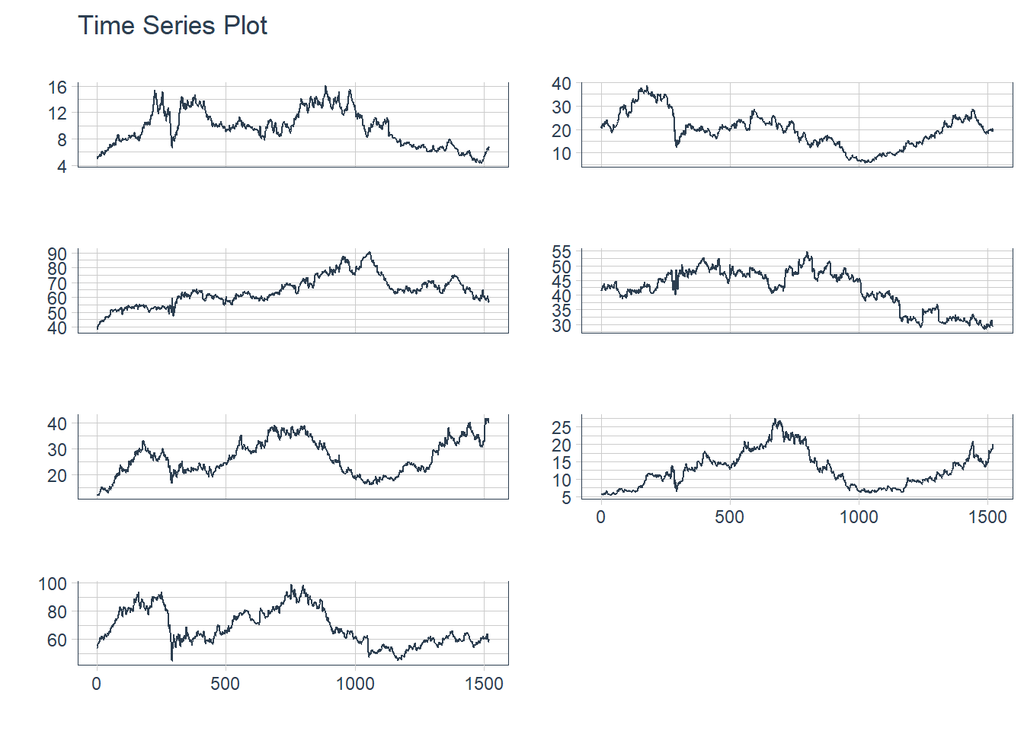

```r
portfolioPrices |> as.data.frame() |>
  mutate(
    time = seq_along(GIS)
  ) |>
  pivot_longer(
    !time,
    names_to = "Variables",
    values_to = "Value"
  ) |>
  group_by(Variables) |>
  plot_time_series(
    time,
    Value,
    .interactive = F, # Change for TRUE for better visualization
    .facet_ncol = 2,
    .smooth = FALSE
  ) +
  theme(
    strip.background = element_rect(fill = "white", colour = "white")
  )
```